# Report of suicide

## Introduction

The time series of the data set is 1985-2016. This dataset was pulled in 2018 by Kaggle user Rusty from four other datasets, and was built to find correlations of increased suicide rates and socio-economic conditions across the world. The other four datasets are from United Nations Development Program, World Bank, [Szamil] and World Health Organization.

## Plot

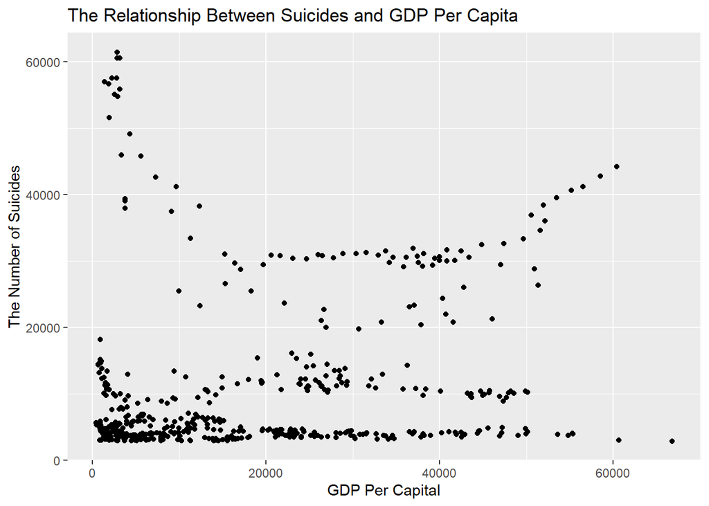

[figure not shown]

[figure not shown]

## Reflection

During the process of analysis of suicides data, I think we sometimes can’t draw direct or affirmative conclusions just from a few time series plots. There are some reasons. First, I observed the data set and found that the number of suicides may just be a small sample of overall suicides cases. In statistics, it’s called sample of population and whether sample is representative is critically important to the accuracy of analysis. Hence I doubt whether this sample can be diverse enough to cover different regions in a country, different age ranges, different careers. The sample chosen sometimes show human beings’ biases and thus cause deviation. The number of sample is also critical, since super large data sets may be hard to collect and analyze, while too small sample can’t tell us the trend. To conclude, in the process of analyzing data, we first should pay attention to the data source and reflect whether it shows any biases, and then analyze it from different angles.

## Apendix

Code file: analysis.R